# PRS_jaccard

Author

Sarah Urbut

Published

March 7, 2024

## Jaccard Index

In this workbook, I compare the 27 socres for CAD to see if the individuals who rank in the top 5, 10 or 20% are similar across scores, and then compare with a permuted null distribution.

## Introduction

This analysis aims to evaluate the overlap between different scores assigned to individuals using the Jaccard index. We further assess the significance of these overlaps by comparing them against a null distribution generated through permutation testing.

## Methodology

### Calculating the Jaccard Index

The Jaccard index is a statistical measure used to gauge the similarity and diversity between sample sets. It is defined as the size of the intersection divided by the size of the union of the sample sets.

#### Formula

where ( A ) and ( B ) are two sets.

### Generating Empirical P-Values

To assess the significance of our observed Jaccard indices, we perform permutation tests. This involves creating a null distribution of the Jaccard index by randomly permuting the score assignments and recalculating the indices for these permuted data.

```r
library(data.table)
library(ggplot2)
df <- fread("codefrombuu/sarah/pheno_prs_cad.txt")
d=df[, .SD, .SDcols = patterns("PGS")]
d=data.frame(apply(d,2,scale))
d$id=df$IID
dt=df=data.table(d)
prs_columns <- c(grep("PGS", names(df), value = TRUE),grep("PRS",names(df), value = TRUE))
```

# Calculate Jaccard

```r
setDT(df)  # Convert df to a data.table for efficiency


# Number of permutations
n_permutations <- 1000


# Prepare storage for permuted Jaccard indices
percentiles <- c(0.05, 0.10, 0.20)
permutation_results = array(NA, dim = c(length(percentiles), n_permutations))
normal_ranks = scale(rnorm(n = nrow(dt)))

for (i in 1:length(percentiles)) {
  pct = percentiles[i]
  jaccard_indices <- vector("list", n_permutations)

  for (j in 1:n_permutations) {
    # Permute each score column independently

    permuted_score1 <-
      sample(normal_ranks,
             size = length(normal_ranks),
             replace = F)
    permuted_score2 <-
      sample(normal_ranks,
             size = length(normal_ranks),
             replace = F)

    # Determine the top X% in each permuted score
    top_flags1 <-
      permuted_score1 > quantile(permuted_score1, 1 - pct)
    top_flags2 <-
      permuted_score2 > quantile(permuted_score1, 1 - pct)
    top_intersection <-
      length(intersect(which(top_flags1 == TRUE), which(top_flags2 == TRUE)))
    top_union <-
      length(union(which(top_flags1 == TRUE), which(top_flags2 == TRUE)))
    permutation_results[i, j] <- top_intersection / top_union
  }
}




# Function to calculate Jaccard index
calculate_jaccard <- function(vec1, vec2) {
  top_intersection = sum(vec1 & vec2)
  top_union = sum(vec1 | vec2)
  if (top_union == 0) return(NA)  # Avoid division by zero
  return(top_intersection / top_union)
}
```

# Observed Restuls

```r
prs_columns <- colnames(df)[-ncol(df)]  # Example; define this with your actual score columns

# Prepare matrix to store observed Jaccard indices
observed_jaccards <- array(NA, dim = c(length(prs_columns), length(prs_columns), length(percentiles)))
dimnames(observed_jaccards) <- list(prs_columns, prs_columns, as.character(percentiles))

# Calculate observed Jaccard indices
for (pct_idx in seq_along(percentiles)) {
    pct <- percentiles[pct_idx]
    for (col1 in prs_columns) {
        for (col2 in prs_columns) {
            if (col1 != col2) {
                top_1 <- df[[col1]] > quantile(df[[col1]], 1 - pct, na.rm = TRUE)
                top_2 <- df[[col2]] > quantile(df[[col2]], 1 - pct, na.rm = TRUE)
                observed_jaccards[[col1, col2, as.character(pct)]] <- calculate_jaccard(top_1, top_2)
            }
        }
    }
}
```

# Heatmaps of Jaccard

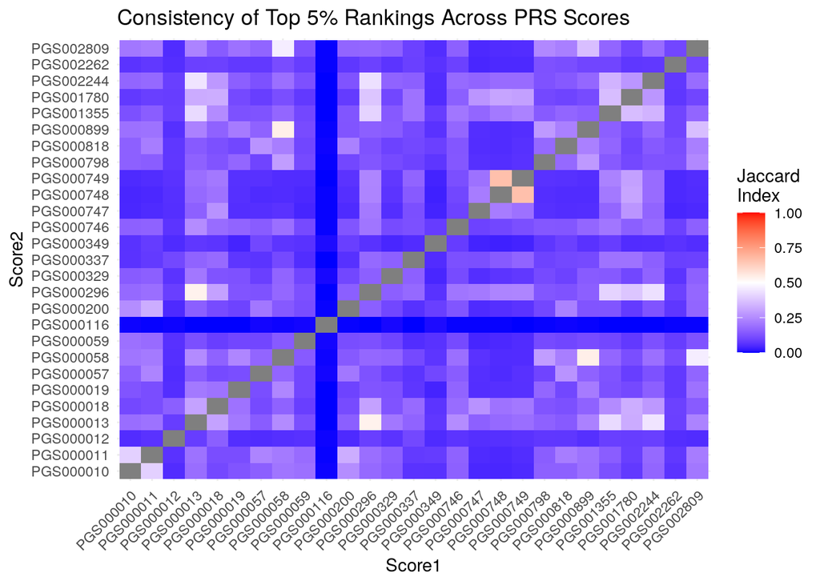

```r
# Visualize the consistency matrix

melted_consistency_matrix <- melt(observed_jaccards[,,"0.05"], varnames = c("Score1", "Score2"))
ggplot(melted_consistency_matrix, aes(x = Score1, y = Score2, fill = value)) +
  geom_tile() +
  scale_fill_gradient2(low = "blue", high = "red", midpoint = 0.5, mid = "white", limit = c(0, 1), name = "Jaccard\nIndex") +
  theme_minimal() +
  theme(axis.text.x = element_text(angle = 45, hjust = 1)) +
  labs(title = "Consistency of Top 5% Rankings Across PRS Scores")
```

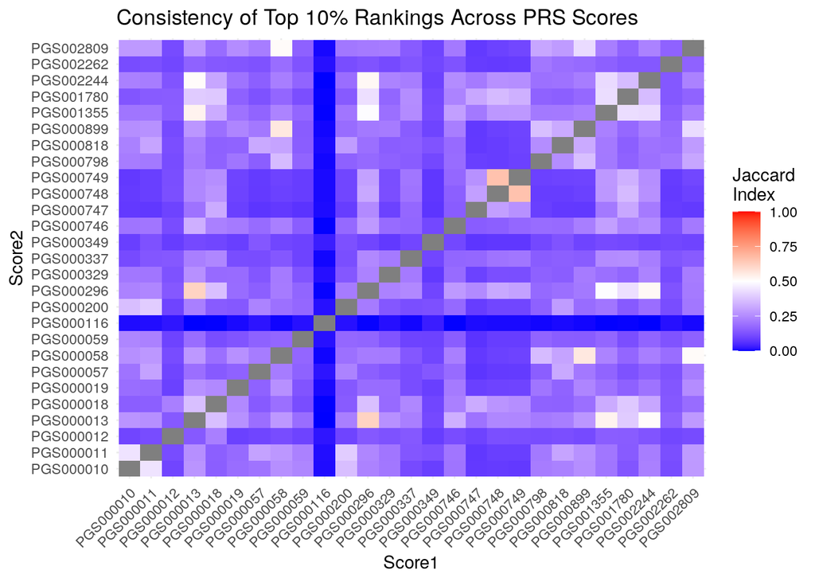

```r
melted_consistency_matrix <- melt(observed_jaccards[,,"0.1"], varnames = c("Score1", "Score2"))
ggplot(melted_consistency_matrix, aes(x = Score1, y = Score2, fill = value)) +
  geom_tile() +
  scale_fill_gradient2(low = "blue", high = "red", midpoint = 0.5, mid = "white", limit = c(0, 1), name = "Jaccard\nIndex") +
  theme_minimal() +
  theme(axis.text.x = element_text(angle = 45, hjust = 1)) +
  labs(title = "Consistency of Top 10% Rankings Across PRS Scores")
```

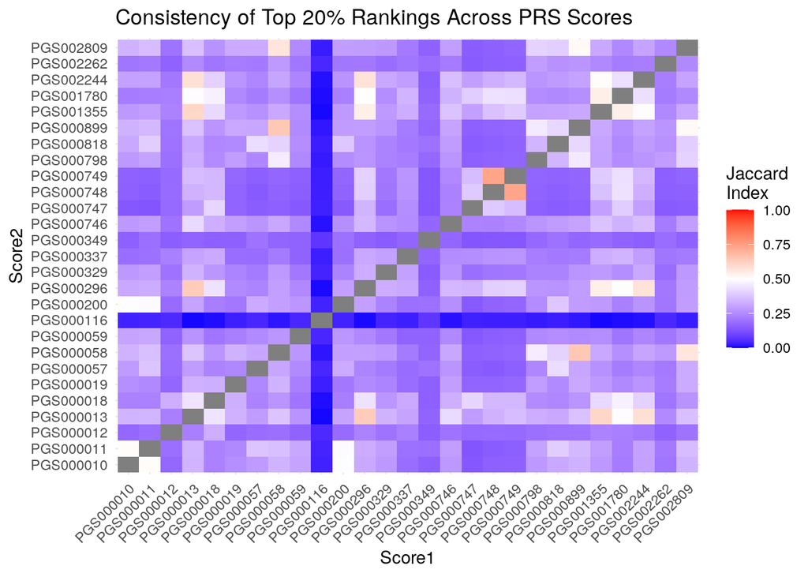

```r
melted_consistency_matrix <- melt(observed_jaccards[,,"0.2"], varnames = c("Score1", "Score2"))
ggplot(melted_consistency_matrix, aes(x = Score1, y = Score2, fill = value)) +
  geom_tile() +
  scale_fill_gradient2(low = "blue", high = "red", midpoint = 0.5, mid = "white", limit = c(0, 1), name = "Jaccard\nIndex") +
  theme_minimal() +
  theme(axis.text.x = element_text(angle = 45, hjust = 1)) +
  labs(title = "Consistency of Top 20% Rankings Across PRS Scores")
```

Observe Jaccards for each

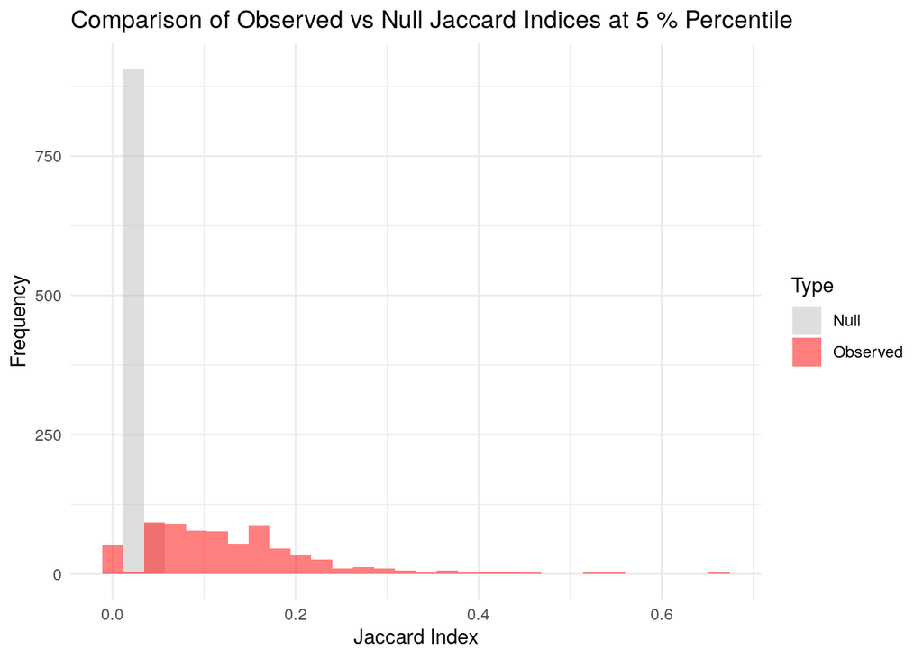

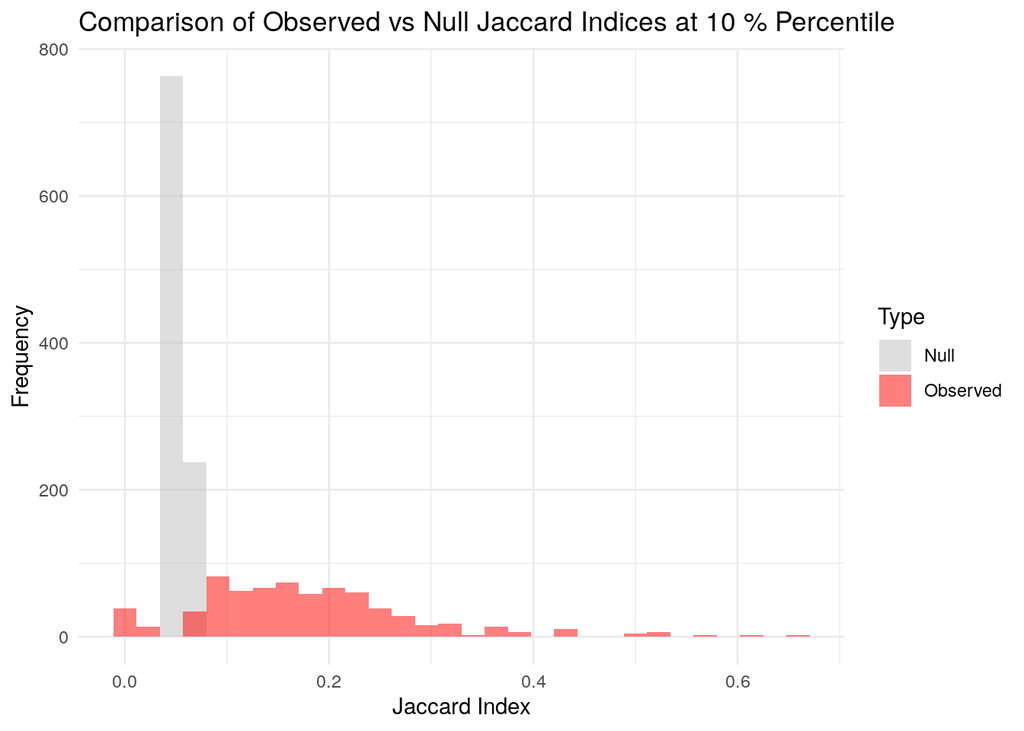

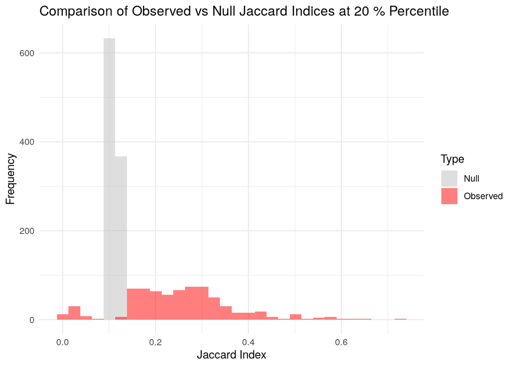

```r
# Loop through each percentile and plot
for (i in seq_along(percentiles)) {
    pct <- percentiles[i]

    # Prepare observed data
    observed_pct <- observed_jaccards[,, as.character(pct)]
    observed_flat <- as.vector(observed_pct)
    observed_flat <- observed_flat[!is.na(observed_flat)]  # Remove NA values

    # Prepare null distribution data
    null_dist <- unlist(permutation_results[i, ])

    # Data for plotting
    data_hist <- data.frame(
        Value = c(observed_flat, null_dist),
        Type = rep(c("Observed", "Null"), c(length(observed_flat), length(null_dist)))
    )

    # Plotting
    p <- ggplot(data_hist, aes(x = Value, fill = Type)) +
        geom_histogram(position = 'identity', alpha = 0.5, bins = 30) +
        scale_fill_manual(values = c("Null" = "grey", "Observed" = "red")) +
        labs(title = paste("Comparison of Observed vs Null Jaccard Indices at", pct*100, "% Percentile"),
             x = "Jaccard Index", y = "Frequency") +
        theme_minimal()

    print(p)
}
```

# Compare P values

```r
# Prepare matrix to store p-values
p_values_upper <- array(NA, dim = c(length(prs_columns), length(prs_columns), length(percentiles)))
dimnames(p_values_upper) <- list(prs_columns, prs_columns, as.character(percentiles))

# Calculate p-values for upper triangle
for (pct_idx in seq_along(percentiles)) {
    pct <- percentiles[pct_idx]
    for (i in 1:(length(prs_columns)-1)) {
        for (j in (i+1):length(prs_columns)) {
            null_dist <- permutation_results[pct_idx, ]
            observed_value <- observed_jaccards[i, j, as.character(pct)]
            p_values_upper[i, j, as.character(pct)] <- sum(null_dist >= observed_value) / n_permutations
        }
    }
}
```

# Now plot the empirical p value distribution

here we compare the p value for the times that the observed p value for each comparison is exceeded by the null

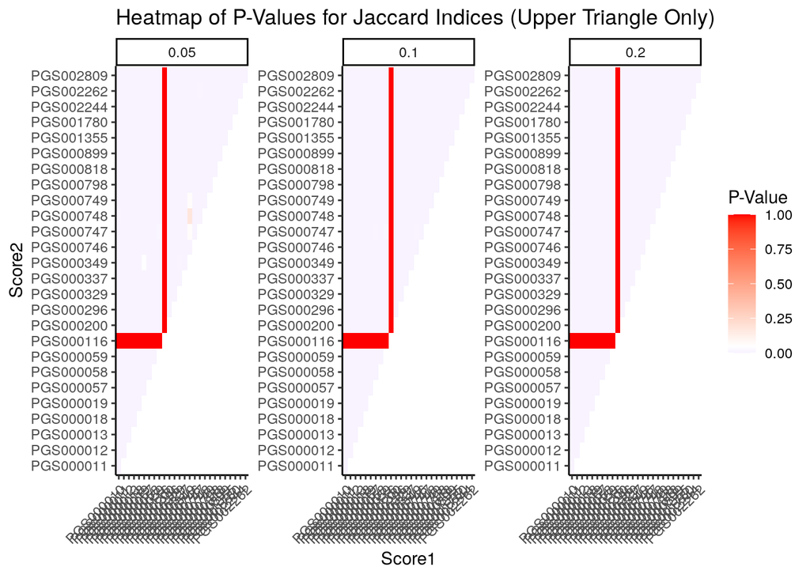

```r
# Convert p-values to a data frame for easier handling
p_values_df <- melt(p_values_upper, varnames = c("Score1", "Score2", "Percentile"), value.name = "PValue")
p_values_df <- p_values_df[!is.na(p_values_df$PValue), ]  # Remove NA entries

# Summary table of p-values
library(dplyr)
summary_table <- p_values_df %>%
    group_by(Score1, Score2, Percentile) %>%
    summarise(MeanPValue = mean(PValue),.groups = 'drop')

# Print summary
#print(summary_table)

# Optionally, create a heatmap of p-values for a visual summary
library(ggplot2)
p <- ggplot(p_values_df, aes(x = Score1, y = Score2, fill = PValue)) +
    geom_tile() +
    facet_wrap(~ Percentile, scales = "free")+
    scale_fill_gradient2(low = "blue", high = "red", midpoint = 0.05, limit = c(0, 1), name = "P-Value") +
    theme_classic() +
    theme(axis.text.x = element_text(angle = 45, hjust = 1)) +
    labs(title = "Heatmap of P-Values for Jaccard Indices (Upper Triangle Only)")

print(p)
```